# freqdemod-quickstart-2

### Author information

John A. Marohn (jam99@cornell.edu)  
Department of Chemistry and Chemical Biology  
Cornell University  
Ithaca, NY USA; 14853-1301

### Date

2014/06/30 -- 2014/07/01

### Abstract

We generate a frequency-modulated sine-wave signal and use `freqdemod` to recover the signal's frequency *vs* time.

## Preliminaries

We first have to tell Python where to find the freqdemod module. Since we are running this file from the /docs directory of the module diretory, we have to tell sys.path to look one level up to find the module.

```python
import os, sys
module_path = os.path.abspath(os.path.join(os.getcwd(), '..'))
sys.path.append(module_path)
```

Now we are ready to load the module:

```python
from freqdemod import Signal
```

## Create a frequency-modulated sine wave

Set the digitization frequency to 100 kHz, corresponding to a time step of 10 us. We want a signal with quite a few points, say 128k = 128 x 1024 = 131072 points. The duration of the signal will thus be 131072 x 10E-6 = 1.31072 seconds.

The sine wave has an initial frequency of 4 kHz. Between 0.25s and 0.75s, the frequency is ramped linearly to 6 kHz. It remains 6 kHz until the end of the signal.

```python
import math
import numpy as np
import matplotlib.pyplot as plt
%matplotlib inline
```

Set up the frequency-ramped sine wave. This takes quite a bit of care!

```python
fd = 100E3
dt = 1/fd

f_start = 4.000E3
f_end = 6.000E3

# time array

t1 = dt*np.arange(int(round(0.25/dt)))
t2 = dt*np.arange(int(round((0.75-0.25)/dt)))
t3 = dt*np.arange(128*1024-t1.size-t2.size)

t2plus = t2+t1[-1]+dt
t3plus = t3+t2plus[-1]+dt

t = np.append(np.append(t1,t2plus),t3plus)

# frequency array

f1 = f_start*np.ones(t1.size)
f2 = f_start + t2*(f_end-f_start)/(t2[-1]-t2[0])
f3 = f_end*np.ones(t3.size)

f = np.append(np.append(f1,f2),f3)

# phase accumulator

p = np.zeros(t.size)
p[0] = 0.0

for k in np.arange(1,t.size):
    p[k] = p[k-1] + dt*f[k-1]

p = 2*np.pi*p

# the signal

x = np.cos(p)
```

Now check out the arrays

```python
print "total number of time points: ", t.size
print "number of points in t1: ", t1.size
print "number of points in t2: ", t2.size
print "number of points in t3: ", t3.size
print "number of points in f: ", f.size
```

```
total number of time points:  131072
number of points in t1:  25000
number of points in t2:  50000
number of points in t3:  56072
number of points in f:  131072
```

```python
print "time array ==>"
print "  near first transition: ", 1E6*t[t1.size-3:t1.size+3]
print "  near second transition", 1E6*t[t1.size+t2.size-3:t1.size+t2.size+3]
print "  at end = ", 1E6*t[-3:]
```

```
time array ==>
  near first transition:  [ 249970.  249980.  249990.  250000.  250010.  250020.]
  near second transition [ 749970.  749980.  749990.  750000.  750010.  750020.]
  at end =  [ 1310690.  1310700.  1310710.]
```

```python
print "frequency ramp start: ", f[0:3]
print "frequency ramp end: ", f[-3:]
```

```
frequency ramp start:  [ 4000.  4000.  4000.]
frequency ramp end:  [ 6000.  6000.  6000.]
```

```python
print "phase array ==>"
print "  near first transition: ", p[t1.size-3:t1.size+3]/(2*np.pi)
print "  near second transition", p[t1.size+t2.size-3:t1.size+t2.size+3]/(2*np.pi)
print "  at end = ", 1E6*p[-3:]
```

```
phase array ==>
  near first transition:  [  999.88        999.92        999.96       1000.         1000.04
  1000.0800004]
  near second transition [ 3499.8200012  3499.8800004  3499.94       3500.         3500.06       3500.12     ]
  at end =  [  4.31286636e+10   4.31290406e+10   4.31294176e+10]
```

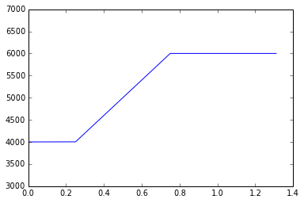

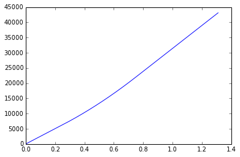

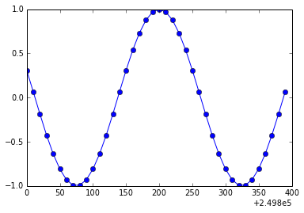

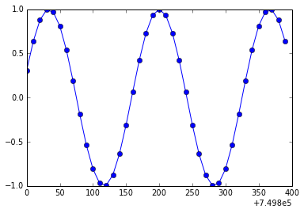

```python
plt.plot(t,f)
plt.ylim([3E3,7E3])
plt.show()

plt.plot(t,p)
plt.show()

trans1 = list(np.arange(t1.size-20,t1.size+20))
plt.plot(1E6*t[trans1],x[trans1],"o-")
plt.show()

trans2 = list(np.arange(t1.size+t2.size-20,t1.size+t2.size+20))
plt.plot(1E6*t[trans2],x[trans2],"o-")
plt.show()
```

## Demodulate it

```python
S = Signal(x,"x","nm",1/fd)
S.binarate("middle")
S.window(1.0E-3)
S.fft()
S.filter(bw=5.0E3)
S.ifft()
S.trim()
print(S)
```

```
Signal
======
signal name: x
signal unit: nm
signal lenth = 131072
time step = 10.000 us
rms = 0.7071
max = 1
min = -1

Signal Report
=============
* Add a signal x[nm] of length 131072 and time step 10.000 us.

* Truncate the signal to be 131072 points long, a power of two. This was done by chopping points off the beginning and end of the signal array, that is, by using points 0 up to 131072.

* Window the signal with a rising/falling blackman filter having a rise/fall time of 1000.000 us (100 points).

* Fourier transform the windowed signal.

* Reject negative frequencies, apply a bandpass filter of bandwidth 5000.0 Hz & order 50, and set the delay time to 250.0 us.

* Apply an inverse Fourier transform.

* Remove the leading and trailing ripple from the complex signal. Compute the signal phase and amplitude.
```

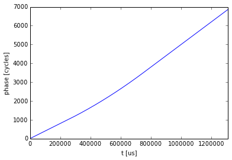

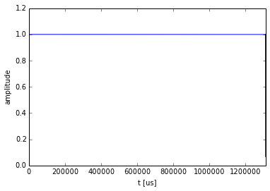

```python
plt.plot(S.signal['t']*1E6,S.signal['theta'])
plt.xlim(0,S.signal['t_original'][-1]*1E6)
plt.ylabel("phase [cycles]")
plt.xlabel("t [us]")
plt.show()

plt.plot(S.signal['t']*1E6,S.signal['a'])
plt.xlim(0,S.signal['t_original'][-1]*1E6)
plt.ylabel("amplitude")
plt.xlabel("t [us]")
plt.show()
```

Pick out 1000 points of data near the beginning and near the end. Fit the phase *vs* time data to a line. We see that we recover the expected intial and final frequencies.

```python
zf = np.polyfit(S.signal['t'][1000:2000], S.signal['theta'][1000:2000], 1)
print "Best-fit frequency = {0:.3f} Hz".format(zf[0])

zf = np.polyfit(S.signal['t'][-2000:-1000], S.signal['theta'][-2000:-1000], 1)
print "Best-fit frequency = {0:.3f} Hz".format(zf[0])
```

```
Best-fit frequency = 4000.000 Hz
Best-fit frequency = 6000.000 Hz
```

## Extract the frequency as a function of time: Try 1

Some points have been removed from the array to eliminate filter ripple. We can see there are fewer points than the original 131072 points.

```python
S.signal['theta'].size
```

```
131022
```

We want to break the data into 10 ms chunks and fit each chunk to a line. We thus want to break the data into sub-arrays of length

```python
ct = int(round(10.0E-3/dt))
print ct
```

```
1000
```

Each chunk should be 1000 points long and there should be 131 of them:

```python
n = ct*int(round(S.signal['theta'].size/ct))
s_sub = S.signal['theta'][0:n].reshape((n/ct,ct))

print s_sub.shape
```

```
(131, 1000)
```

Now set up two time arrays.

1. The first array, `t_chunk`, is the time array we will use as the x-axis for curve fitting. The initial element of this array will not be zero because of the trimming.
2. The second array, `t_fit`, the a time array will will plot the curve-fit results against.

```python
t_chunck = S.signal['t'][0:ct]
print "t_chunck.shape = ", t_chunck.shape
print "first and last t_chunck values [us]: ", \
    1E6*np.array([t_chunck[0], t_chunck[-1]])

t_fit = S.signal['t'][0:n:ct]
print "t_fit.shape = ", t_fit.shape
print "first few and last few t_fit values [us]: ", \
    1E6*np.array([t_fit[0], t_fit[1], t_fit[2], t_fit[-1]])
```

```
t_chunck.shape =  (1000,)
first and last t_chunck values [us]:  [   250.  10240.]
t_fit.shape =  (131,)
first few and last few t_fit values [us]:  [  2.50000000e+02   1.02500000e+04   2.02500000e+04   1.30025000e+06]
```

```python
a = s_sub[:,:,np.newaxis][:,0,:]
b = np.ones(ct)
c = a*b

print a.shape
print b.shape
print c.shape

print c[0,0:3]
print c[1,0:3]
```

```
(131, 1)
(1000,)
(131, 1000)
[ 0.99986037  0.99986037  0.99986037]
[ 41.  41.  41.]
```

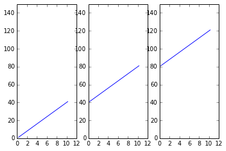

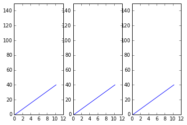

```python
plt.subplot(131)
plt.plot(1E3*t_chunck,s_sub[0,:])
plt.ylim([0,150])

plt.subplot(132)
plt.plot(1E3*t_chunck,s_sub[1,:])
plt.ylim([0,150])

plt.subplot(133)
plt.plot(1E3*t_chunck,s_sub[2,:])
plt.ylim([0,150])

plt.show()

a = s_sub[:,:,np.newaxis][:,0,:]
b = np.ones(ct)
c = a*b

s_sub_reset = s_sub - c

plt.subplot(131)
plt.plot(1E3*t_chunck,s_sub_reset[0,:])
plt.ylim([0,150])

plt.subplot(132)
plt.plot(1E3*t_chunck,s_sub_reset[1,:])
plt.ylim([0,150])

plt.subplot(133)
plt.plot(1E3*t_chunck,s_sub_reset[2,:])
plt.ylim([0,150])

plt.show()
```

```python
print s_sub_reset.shape
print s_sub_reset[:,0].shape
```

```
(131, 1000)
(131,)
```

Curve fit Method 1.

```python
def myfunction(x):
    return np.polyfit(t_chunck, x, 1)[0]

import time

start = time.time()
zf = np.apply_along_axis(myfunction, axis=1, arr=s_sub_reset)
stop = time.time()

print "Time to execute curve fit = {0:.3f} ms".format(1E3*(stop-start))
```

```
Time to execute curve fit = 54.746 ms
```

Curve fit Method 2.

```python
import time
zf = np.zeros(s_sub_reset[:,0].size)
start = time.time()
for k in np.arange(s_sub_reset[:,0].size):
    zf[k] = np.polyfit(t_chunck, s_sub_reset[k,:], 1)[0]
stop = time.time()

print "Time to execute curve fit = {0:.3f} ms".format(1E3*(stop-start))
```

```
Time to execute curve fit = 57.489 ms
```

Plot the curve fit results

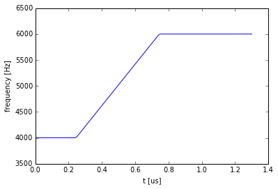

```python
plt.plot(t_fit,zf)
plt.xlabel("t [us]")
plt.ylabel("frequency [Hz]")
plt.show()
```

## Extract the frequency as a function of time: Try 2

Curve fit Method 3. We want to avoid the loop. Apply the same re-setting trick to both the time array and the phase array. Start by computing the the number of points:

```python
dt_chunk_target = 1000.07E-6

n_per_chunk = int(round(dt_chunk_target/dt))
dt_chunk = dt*n_per_chunk
n_tot_chunk = int(round(S.signal['theta'].size/n_per_chunk))
n_total = n_per_chunk*n_tot_chunk

print "points per chunk =", n_per_chunk
print "time per chunk = {0:.3f} us".format(1E6*dt_chunk)
print "number of chunks =", n_tot_chunk
print "number of points analyzed =", n_total
```

```
points per chunk = 100
time per chunk = 1000.000 us
number of chunks = 1310
number of points analyzed = 131000
```

Now rearrange the arrays, first the phase, then time.

```
rearranging the phase into an array of shape (1310, 100)
```

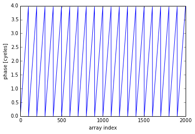

```python
s_sub = S.signal['theta'][0:n_total].reshape((n_tot_chunk,n_per_chunk))
print "rearranging the phase into an array of shape {}".format(s_sub.shape)

a = s_sub[:,:,np.newaxis][:,0,:]
b = np.ones(n_per_chunk)
c = a*b

s_sub_reset = s_sub - c

plt.plot(s_sub_reset.flatten()[0:n_per_chunk*20])
plt.xlabel("array index")
plt.ylabel("phase [cyeles]")
plt.show()
```

```
rearranging the time into an array of shape (1310, 100)
```

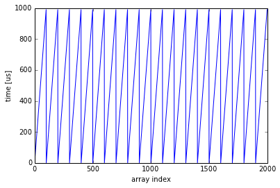

```python
t_sub = S.signal['t'][0:n_total].reshape((n_tot_chunk,n_per_chunk))
print "rearranging the time into an array of shape {}".format(t_sub.shape)

a = t_sub[:,:,np.newaxis][:,0,:]
b = np.ones(n_per_chunk)
c = a*b

t_sub_reset = t_sub - c

plt.plot(1E6*t_sub_reset.flatten()[0:n_per_chunk*20])
plt.xlabel("array index")
plt.ylabel("time [us]")
plt.show()
```

Impliment a least-squares fit "by hand". We just want the slope:

```python
SXY = np.sum(t_sub_reset*s_sub_reset,axis=1)
SX = np.sum(t_sub_reset,axis=1)
SY = np.sum(s_sub_reset,axis=1)
SXX = np.sum(t_sub_reset*t_sub_reset,axis=1)

slope = (n_per_chunk*SXY-SX*SY)/(n_per_chunk*SXX-SX*SX)

print "the slope array has a shape of {0}".format(slope.shape)
```

```
the slope array has a shape of (1310,)
```

Plot the result -- nice!

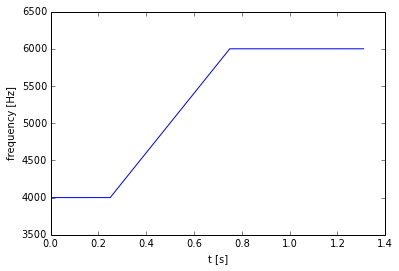

```python
plt.plot(t_sub[:,0],slope)
plt.xlabel("t [s]")
plt.ylabel("frequency [Hz]")
plt.show()
```

Now put the whole procedure together and time it. To be fair, we will not include the setup, just the fitting part of the procedure. The speed up using this brute-force procedure is **approximately a factor of 5**. We do have to store many more arrays.

```python
import time

start = time.time()

s_sub = S.signal['theta'][0:n_total].reshape((n_tot_chunk,n_per_chunk))
s_sub_reset = s_sub - s_sub[:,:,np.newaxis][:,0,:]*np.ones(n_per_chunk)

t_sub = S.signal['t'][0:n_total].reshape((n_tot_chunk,n_per_chunk))
t_sub_reset = t_sub - t_sub[:,:,np.newaxis][:,0,:]*np.ones(n_per_chunk)

SXY = np.sum(t_sub_reset*s_sub_reset,axis=1)
SX = np.sum(t_sub_reset,axis=1)
SY = np.sum(s_sub_reset,axis=1)
SXX = np.sum(t_sub_reset*t_sub_reset,axis=1)

slope = (n_per_chunk*SXY-SX*SY)/(n_per_chunk*SXX-SX*SX)

stop = time.time()

print "Time to execute curve fit = {0:.3f} ms".format(1E3*(stop-start))
```

```
Time to execute curve fit = 10.229 ms
```

## Quality of the frequency fit

We want to compare the best-fit frequency to the known frequency. We have to evaluate the known frequency at just the right time. This is tricky -- we have to account for the filter delay.

Take a look at size of the original arrays and the chunk-ed down arrays:

```python
# the original data arrays

print t.shape
print f.shape
```

```
(131072,)
(131072,)
```

```python
# the best-fit arrays

print t_sub[:,0].shape
print slope.shape
```

```
(1310,)
(1310,)
```

```python
# the first few starting times of the chunked-down time array

print t_sub[0,0]
print t_sub[1,0]
```

```
0.00025
0.00125
```

We want to extract the known frequencies at the times when `t == t_sub[:,0]`. How to do this? We know the time offset due to the filter,

```python
S.signal['td']
```

```
0.00025
```

which we can convert to an array index

```python
id = int(S.signal['td']/S.signal['dt'])
print "delay index =",id
```

```
delay index = 25
```

As a check, let us recreate the chunked time axis from this known delay and the already computed `n_per_chunk`.

```python
t_theory = t[id:-1:n_per_chunk][0:n_tot_chunk]
t_theory.size
```

```
1310
```

We can see that the intial times in the rccreated array agree exactly with the data in the chunked time array. Good -- this tells us we have chosen the correct array offsets.

```python
print t_sub[0:3,0]
print t_theory[0:3]
```

```
[ 0.00025  0.00125  0.00225]
[ 0.00025  0.00125  0.00225]
```

Now obtain the expected slope by evaluating the known slope at the same array offests. We can now compare the known frequency to the measured frequency.

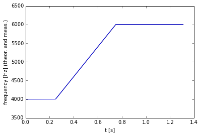

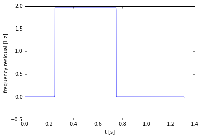

```
integration period = 1.31 s
rms frequency error = 1.21085066726 Hz
```

```python
slope_theory = f[id:-1:n_per_chunk][0:n_tot_chunk]

plt.plot(t_theory,slope_theory,'k-')
plt.plot(t_sub[:,0],slope,'b-')
plt.xlabel("t [s]")
plt.ylabel("frequency [Hz] (theor. and meas.)")
plt.show()

resid = slope - slope_theory
plt.plot(t_theory,resid)
plt.xlabel("t [s]")
plt.ylabel("frequency residual [Hz]")
plt.show()

T_total = dt_chunk*np.ones(resid.size).sum()
mean_square_error = (dt_chunk*resid*resid).sum()/T_total

print "integration period = {} s".format(T_total)
print "rms frequency error = {0} Hz".format(math.sqrt(mean_square_error))
```

It is hard to see the difference between the calculated and the known frequency. Computing the residual error is more revealing. Plotting the residual error we see a large 2 Hz error in the measured frequency during the ramp. Given that there is no noise in the data, this error is significant: 2/4000 = 0.05 percent. Surprisingly, the difference between the measured and the known frequency is *constant* during the ramp.

...

Ok, paper-and-pencil calculations tell me that the least squares fit really measures the frequency at the *center* of the integration window. To account for this correction, we need to compare to the known frequency at an array index `n_per_chunk/2` later than we did above. Adding a `-1` shift to the time index further improves the agreement.

Making these two corrections -- the expected `n_per_chunk/2` shift and the empirical `-1` shift -- the agreement improves dramatically. The rms error drops from 1.2 Hz to 0.002 Hz.

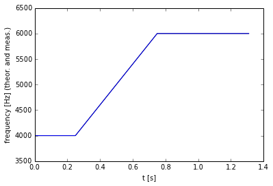

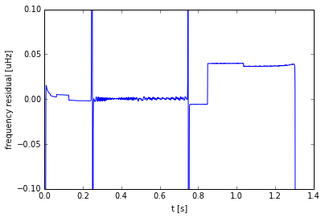

```
integration period = 1.31 s
rms frequency error = 0.0022156380747 Hz
```

```python
slope_theory = f[id-1+n_per_chunk/2:-1:n_per_chunk][0:n_tot_chunk]

plt.plot(t_theory,slope_theory,'k-')
plt.plot(t_sub[:,0],slope,'b-')
plt.xlabel("t [s]")
plt.ylabel("frequency [Hz] (theor. and meas.)")
plt.show()

resid = slope - slope_theory
plt.plot(t_theory,1E6*resid)
plt.ylim([-0.1,0.1])
plt.xlabel("t [s]")
plt.ylabel("frequency residual [uHz]")
plt.show()

T_total = dt_chunk*np.ones(resid.size).sum()
mean_square_error = (dt_chunk*resid*resid).sum()/T_total

print "integration period = {} s".format(T_total)
print "rms frequency error = {0} Hz".format(math.sqrt(mean_square_error))
```

## Conclusions

- Care must be taken to generate the oscillating signal when the frequency is a function of time. Above I used a phase-advance to construct the oscillating signal.
- We can speed up the curve fitting used to extract the frequency by a factor of 5 or more by implementing our own least-squares slope calculation.
- For a linear frequency ramp, the agreement between measured and expected frequency is excellent, provided one compares the measured frequency to the known frequency evaluated *at the middle of the fitting window*.

## Curve fit revisited

I observe that two of the sums in the least-squares slope calculation can be calculated by hand. This could speed up the slope calculation. Let's repeat the above curve fit:

```python
import time

start = time.time()

s_sub = S.signal['theta'][0:n_total].reshape((n_tot_chunk,n_per_chunk))
s_sub_reset = s_sub - s_sub[:,:,np.newaxis][:,0,:]*np.ones(n_per_chunk)

t_sub = S.signal['t'][0:n_total].reshape((n_tot_chunk,n_per_chunk))
t_sub_reset = t_sub - t_sub[:,:,np.newaxis][:,0,:]*np.ones(n_per_chunk)

SXY = np.sum(t_sub_reset*s_sub_reset,axis=1)
SX = np.sum(t_sub_reset,axis=1)
SY = np.sum(s_sub_reset,axis=1)
SXX = np.sum(t_sub_reset*t_sub_reset,axis=1)

slope = (n_per_chunk*SXY-SX*SY)/(n_per_chunk*SXX-SX*SX)

stop = time.time()

print "Time to execute curve fit = {0:.3f} ms".format(1E3*(stop-start))
```

```
Time to execute curve fit = 8.036 ms
```

Since the time data are equally spaced, we can calculate the `SX` and `SXX` sums by hand in closed form. The measured and calculated values agree exactly.

```python
print "SX measured = {}".format(SX[0])
SXcalc = (S.signal['dt'])*0.50*(n_per_chunk-1)*(n_per_chunk)
print "SX calculated = {}".format(SXcalc)
```

```
SX measured = 0.0495
SX calculated = 0.0495
```

```python
print "SXX measured = {}".format(SXX[0])
SXXcalc = (S.signal['dt'])**2*(1/6.0)*\
    (n_per_chunk)*(n_per_chunk-1)*(2*n_per_chunk-1)
print "SXX calculated = {}".format(SXXcalc)
```

```
SXX measured = 3.2835e-05
SXX calculated = 3.2835e-05
```

We can go back and further simplify the curve fitting by using the calculated values of `SX` and `SXX`.

```python
import time

start = time.time()

s_sub = S.signal['theta'][0:n_total].reshape((n_tot_chunk,n_per_chunk))
s_sub_reset = s_sub - s_sub[:,:,np.newaxis][:,0,:]*np.ones(n_per_chunk)

t_sub = S.signal['t'][0:n_total].reshape((n_tot_chunk,n_per_chunk))
t_sub_reset = t_sub - t_sub[:,:,np.newaxis][:,0,:]*np.ones(n_per_chunk)

# SX = np.sum(t_sub_reset,axis=1)
# SXX = np.sum(t_sub_reset*t_sub_reset,axis=1)

SX = (S.signal['dt'])*0.50*(n_per_chunk-1)*(n_per_chunk)
SXX = (S.signal['dt'])**2*(1/6.0)*\
    (n_per_chunk)*(n_per_chunk-1)*(2*n_per_chunk-1)

SY = np.sum(s_sub_reset,axis=1)
SXY = np.sum(t_sub_reset*s_sub_reset,axis=1)

slope = (n_per_chunk*SXY-SX*SY)/(n_per_chunk*SXX-SX*SX)

stop = time.time()

print "Time to execute curve fit = {0:.3f} ms".format(1E3*(stop-start))
```

```
Time to execute curve fit = 7.064 ms
```

Surprising, not much of an additional speed up. maybe 10 or 20 percent ... There *is* a memory reduction, since there are two fewer large arrays to store. Therefore, use the the calculated `SX` and `SXX`.

## Conclusions

- We can speed up the curve fitting by another small factor (only 10 or 20 percent) while saving memory by using calculated values for two of the sums in the least-squares calculation of the slope.